```r
list.of.packages <- c("expsmooth", "fpp2","fitdistrplus", "logspline","readxl", "xts","forecast", "fma","lmtest", "tseries","Quandl", "fpp","urca", "TSA","tidyverse","gdata","XLConnect")
new.packages <- list.of.packages[!(list.of.packages %in% installed.packages()[,"Package"])]
if(length(new.packages)) install.packages(new.packages,dependencies=TRUE)

library('expsmooth')
library('fpp2')
library('fitdistrplus')
library('logspline')
library('xts')
library('forecast');
library('fma')
library('lmtest')
library('tseries')
library('Quandl')
library('fpp');
library('urca')
library('TSA')
library('readxl')
library('tidyverse')
library('gdata')
#library('XLConnect')
#library('gdata')
#library('gdata')
```

### Combine the data from the 16 files into a single dataset and plot it:

```r
dataPath<-"~/Downloads/Time_Seriese/week4"
setwd(dataPath)
getwd()
```

```
## [1] "/Users/hazim/Downloads/Time_Seriese/week4"
```

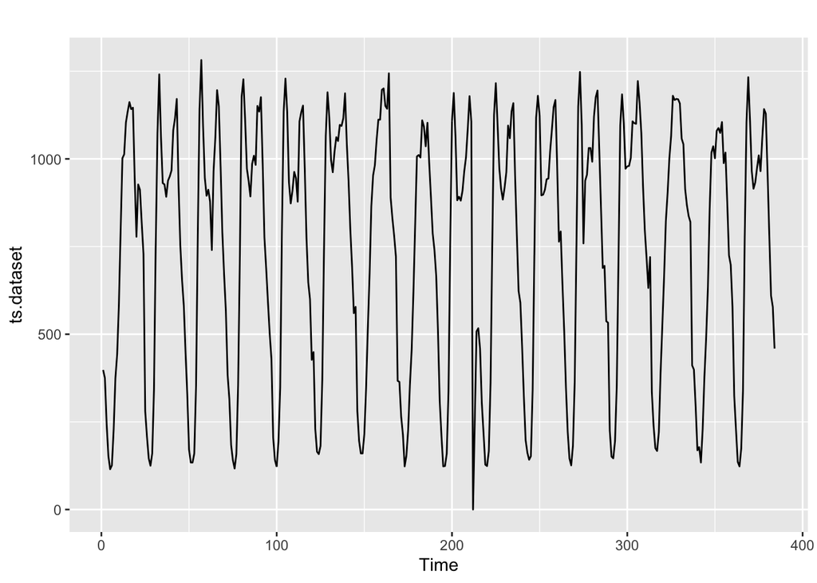

```r
file.list <- list.files(path = dataPath,pattern='*.xls')
df.list <- lapply(file.list, read_xls,sheet = 1, col_names = TRUE,skip = 1, range = cell_cols(c("C", "E")))

for (i in 1:length(df.list)){df.list[[i]]<-
cbind(df.list[[i]],datetime=as.Date(gsub("I-57-", "",gsub(".xls", "", file.list[i])),format="%Y-%B-%d"))
df.list[[i]] <- subset(df.list[[i]], select = -c(SI80) )
df.list[[i]] <- df.list[[i]][-c(1, 2, 27,28), ]
df.list[[i]]$datetime <- as.POSIXct(paste(df.list[[i]]$datetime,df.list[[i]]$Time),format="%Y-%m-%d %H:%M")
}
dataset<-do.call("rbind", df.list)
dataset<-dataset[, c("datetime", "I80E")]
dataset<-dataset[order(dataset$datetime),]
ts.dataset<-ts(dataset$I80E, frequency = 1)

autoplot(ts.dataset)
```

### Split the dataset into a training dataset which includes 6/16/2013 -6/30/2013 samplesand a test dataset which includes 7/1/2013samples.Plot the ACF and PACF,and apply the Augmented Dickey-Fuller Test to check if the training dataset is stationary.

```r
myts.train.ds <- dataset[dataset$datetime<as.Date('2013-07-01'),2]
myts.train.ds<-as.numeric(myts.train.ds)
myts.test.ds  <- dataset[dataset$datetime>as.POSIXct('2013-06-30 23:00:00'),2]
myts.test.ds<-as.numeric(myts.test.ds)
# head(myts.train)
# tail(myts.train)
# head(myts.test)
myts.train<-ts(myts.train.ds, frequency = 24)
myts.test<-ts(myts.test.ds,start = c(7,1), frequency = 1)
fit <- tbats(myts.train)
seasonal <- !is.null(fit$seasonal)
print(paste('Seasonality = ',seasonal))
```

```
## [1] "Seasonality =  TRUE"
```

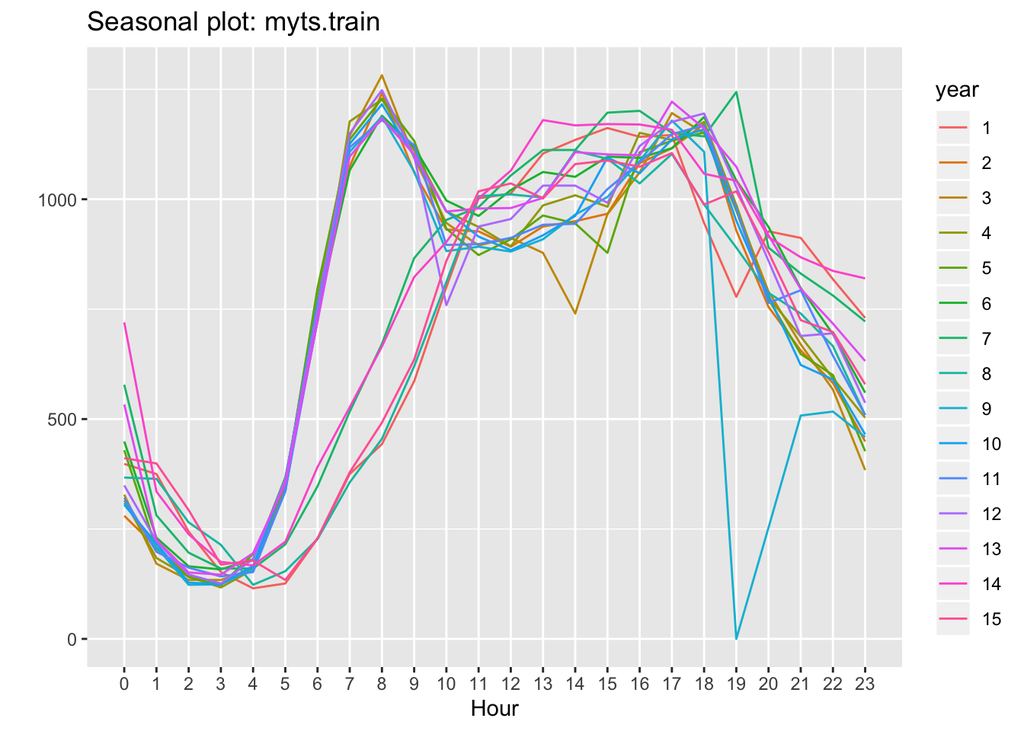

```r
ggseasonplot(myts.train)
```

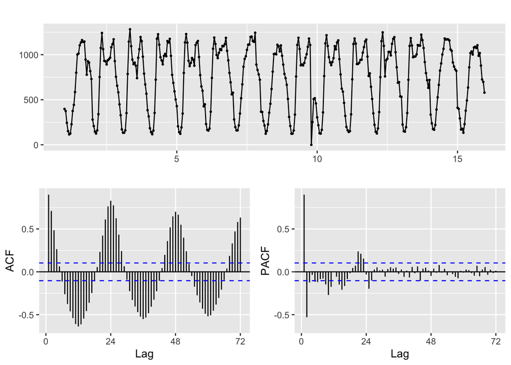

```r
ggtsdisplay(myts.train)
```

```r
adf.test(myts.train)
```

```
##
##  Augmented Dickey-Fuller Test
##
## data:  myts.train
## Dickey-Fuller = -8.2071, Lag order = 7, p-value = 0.01
## alternative hypothesis: stationary
```

`Features:`

`- series is stationary p value in the ADF test is 0.01`

```r
(fit.arima <- auto.arima(myts.train, seasonal = FALSE))
```

```
## Series: myts.train
## ARIMA(3,0,1) with non-zero mean
##
## Coefficients:
##          ar1      ar2     ar3      ma1      mean
##       2.1202  -1.4478  0.2753  -0.9402  746.3552
## s.e.  0.0550   0.1029  0.0543   0.0181    7.7055
##
## sigma^2 estimated as 15246:  log likelihood=-2243.79
## AIC=4499.58   AICc=4499.82   BIC=4522.9
```

```r
(ESACF <- eacf(myts.train))
```

```
## AR/MA
##   0 1 2 3 4 5 6 7 8 9 10 11 12 13
## 0 x x x x o x x x x x x  x  x  x
## 1 x x x x o x x x o o x  x  x  x
## 2 x o x o o o o x x o o  x  o  o
## 3 x o o o o o o o o o o  o  x  o
## 4 x x x o o o o o o o o  o  o  o
## 5 x x o o o o o o o o o  o  o  o
## 6 x x o o o o o o o x o  o  o  o
## 7 x o o o x o o o o x o  o  o  o
```

[output not shown]

[output cut: 30 more lines]

```r
(EACF1 <- Arima(myts.train, order=c(2,0,1)))
```

```
## Series: myts.train
## ARIMA(2,0,1) with non-zero mean
##
## Coefficients:
##          ar1      ar2      ma1      mean
##       1.5858  -0.7163  -0.2946  740.8215
## s.e.  0.0881   0.0785   0.1349   36.9286
##
## sigma^2 estimated as 17045:  log likelihood=-2263.86
## AIC=4537.72   AICc=4537.89   BIC=4557.15
```

```r
(EACF2 <- Arima(myts.train, order=c(3,0,1)))
```

```
## Series: myts.train
## ARIMA(3,0,1) with non-zero mean
##
## Coefficients:
##          ar1      ar2     ar3      ma1      mean
##       2.1202  -1.4478  0.2753  -0.9402  746.3552
## s.e.  0.0550   0.1029  0.0543   0.0181    7.7055
##
## sigma^2 estimated as 15246:  log likelihood=-2243.79
## AIC=4499.58   AICc=4499.82   BIC=4522.9
```

```r
(EACF3 <- Arima(myts.train, order=c(7,0,1)))
```

```
## Series: myts.train
## ARIMA(7,0,1) with non-zero mean
##
## Coefficients:
##          ar1      ar2     ar3     ar4      ar5     ar6      ar7      ma1
##       2.0601  -1.3998  0.1977  0.1425  -0.0978  0.1072  -0.1017  -0.8966
## s.e.  0.0566   0.1235  0.1417  0.1416   0.1413  0.1216   0.0543   0.0233
##           mean
##       746.1268
## s.e.    7.3277
##
## sigma^2 estimated as 14688:  log likelihood=-2235.32
## AIC=4490.63   AICc=4491.26   BIC=4529.49
```

```r
(EACF4 <- Arima(myts.train, order=c(3,0,2)))
```

```
## Series: myts.train
## ARIMA(3,0,2) with non-zero mean
##
## Coefficients:
##          ar1      ar2     ar3      ma1      ma2      mean
##       2.0061  -1.2361  0.1690  -0.8155  -0.1148  746.3411
## s.e.  0.1462   0.2722  0.1382   0.1425   0.1295    7.6959
##
## sigma^2 estimated as 15254:  log likelihood=-2243.4
## AIC=4500.79   AICc=4501.11   BIC=4528
```

```r
(EACF5 <- Arima(myts.train, order=c(2,0,3)))
```

```
## Series: myts.train
## ARIMA(2,0,3) with non-zero mean
##
## Coefficients:
##          ar1      ar2      ma1      ma2      ma3      mean
##       1.8073  -0.8823  -0.6039  -0.2005  -0.1101  746.3445
## s.e.  0.0295   0.0295   0.0611   0.0599   0.0630    7.6818
##
## sigma^2 estimated as 15187:  log likelihood=-2242.6
## AIC=4499.21   AICc=4499.53   BIC=4526.41
```

```r
(EACF6 <- Arima(myts.train, order=c(2,0,2)))
```

```
## Series: myts.train
## ARIMA(2,0,2) with non-zero mean
##
## Coefficients:
##          ar1      ar2      ma1      ma2      mean
##       1.8300  -0.9050  -0.6595  -0.2546  746.3273
## s.e.  0.0233   0.0232   0.0500   0.0479    7.7022
##
## sigma^2 estimated as 15265:  log likelihood=-2244.05
## AIC=4500.1   AICc=4500.34   BIC=4523.42
```

```r
(Arima.AICs <- c(fit.arima=fit.arima$aic,EACF1=EACF1$aic,EACF2=EACF2$aic,EACF3=EACF3$aic,EACF4=EACF4$aic,EACF5=EACF5$aic,EACF6=EACF6$aic))
```

```
## fit.arima     EACF1     EACF2     EACF3     EACF4     EACF5     EACF6
##  4499.584  4537.718  4499.584  4490.633  4500.794  4499.208  4500.100
```

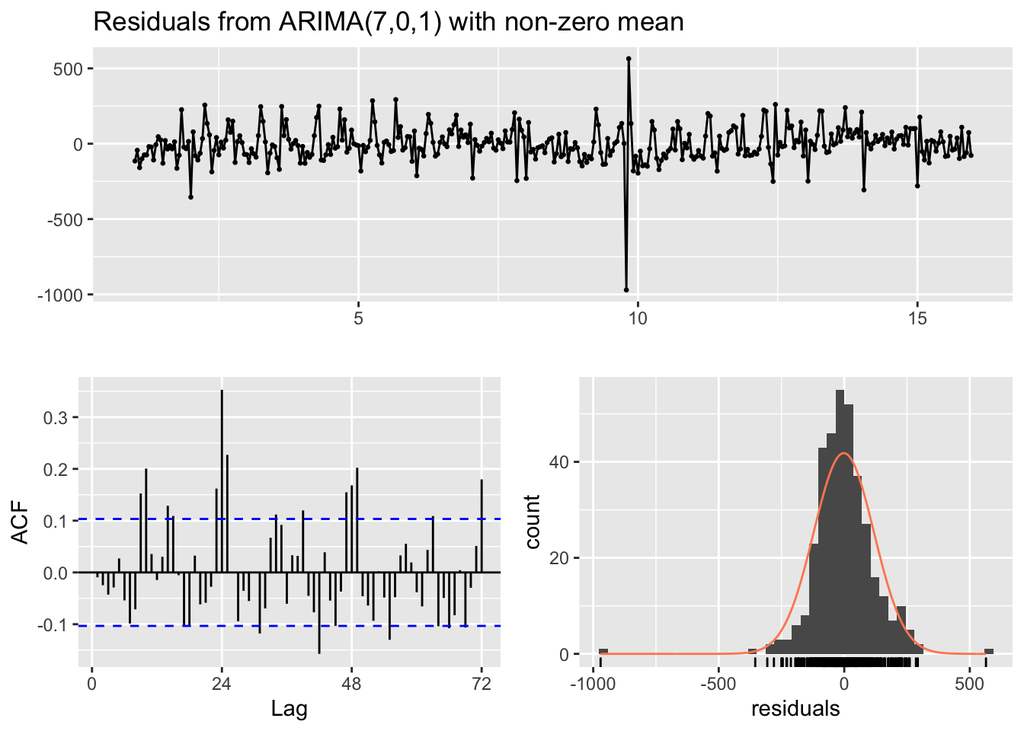

```
##
##  Ljung-Box test
##
## data:  Residuals from ARIMA(7,0,1) with non-zero mean
## Q* = 206.2, df = 39, p-value < 2.2e-16
##
## Model df: 9.   Total lags used: 48
```

```r
checkresiduals(EACF3)
```

`IEACF3 give better model than auto.arima`

### Build a day of the week seasonal Arima(p,d,q)(P,Q,D)s model using the training dataset and R auto.arima() function.

```r
myts.train.day <- ts(data = myts.train.ds,start = c(6,16), frequency = 168)
(fit.arima.day <- auto.arima(myts.train.day, seasonal = TRUE))
```

```
## Series: myts.train.day
## ARIMA(0,1,2)(0,1,0)[168]
##
## Coefficients:
##           ma1      ma2
##       -0.4747  -0.4837
## s.e.   0.0609   0.0603
##
## sigma^2 estimated as 7114:  log likelihood=-1122.08
## AIC=2250.16   AICc=2250.29   BIC=2259.92
```

### Use the Arima(p,d,q)(P,Q,D)s model to forecast for July 1st(which is a Monday). Plot your result.

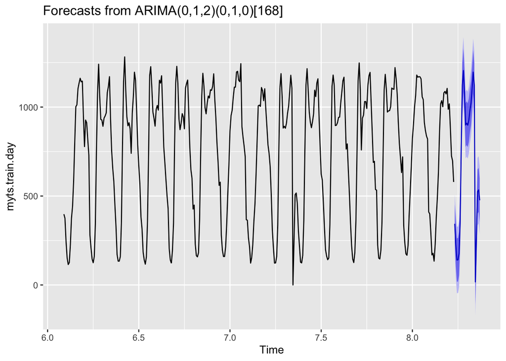

```r
forecast.day<-forecast(fit.arima.day, h= 24)
autoplot(forecast.day)
```

### Build a hour of the day seasonal Arima(p,d,q)(P,Q,D)s model using the training dataset and R auto.arima() function.

```r
myts.train.hour <- ts(data = myts.train.ds, frequency = 24)
(fit.arima.hour <- auto.arima(myts.train.hour, seasonal = TRUE))
```

```
## Series: myts.train.hour
## ARIMA(2,0,1)(2,1,0)[24]
##
## Coefficients:
##          ar1      ar2      ma1     sar1     sar2
##       1.4383  -0.6126  -0.6102  -0.3924  -0.3234
## s.e.  0.1627   0.1057   0.1945   0.0586   0.0550
##
## sigma^2 estimated as 12898:  log likelihood=-2068.54
## AIC=4149.09   AICc=4149.34   BIC=4171.99
```

### Use the Arima(p,d,q)(P,Q,D)s model to forecastfor July 1st (which is a Monday). Plot your result.

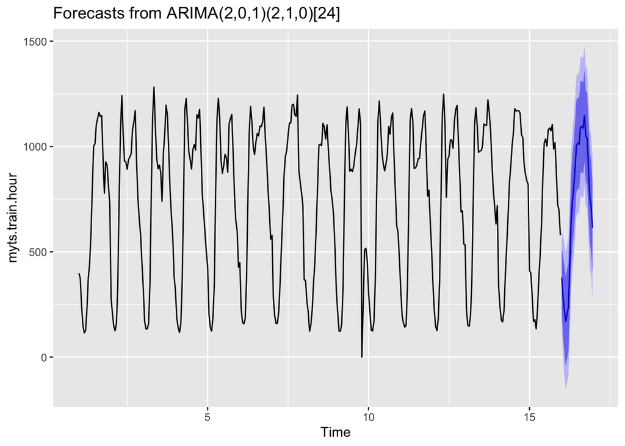

```r
forecast.hour<-forecast(fit.arima.hour, h= 24)
autoplot(forecast.hour)
```

### Compare the forecast of the models for July 1 8:00, 9:00, 17:00 and 18:00

```r
accuracy(forecast.day$mean[c(8,9,17,18)], myts.test[c(8,9,17,18)])
```

```
##                ME     RMSE     MAE       MPE     MAPE
## Test set -23.1284 39.35239 36.9392 -2.162678 3.282775
```

```r
accuracy(forecast.hour$mean[c(8,9,17,18)], myts.test[c(8,9,17,18)])
```

```
##                ME     RMSE     MAE      MPE     MAPE
## Test set 231.3206 338.9581 247.403 19.75138 21.25712
```

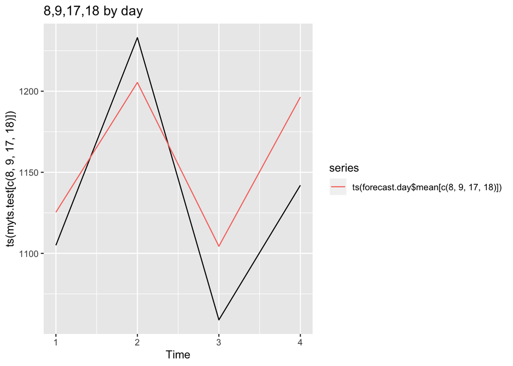

```r
autoplot(ts(myts.test[c(8,9,17,18)]))+ autolayer(ts(forecast.day$mean[c(8,9,17,18)]))+ggtitle("8,9,17,18 by day")
```

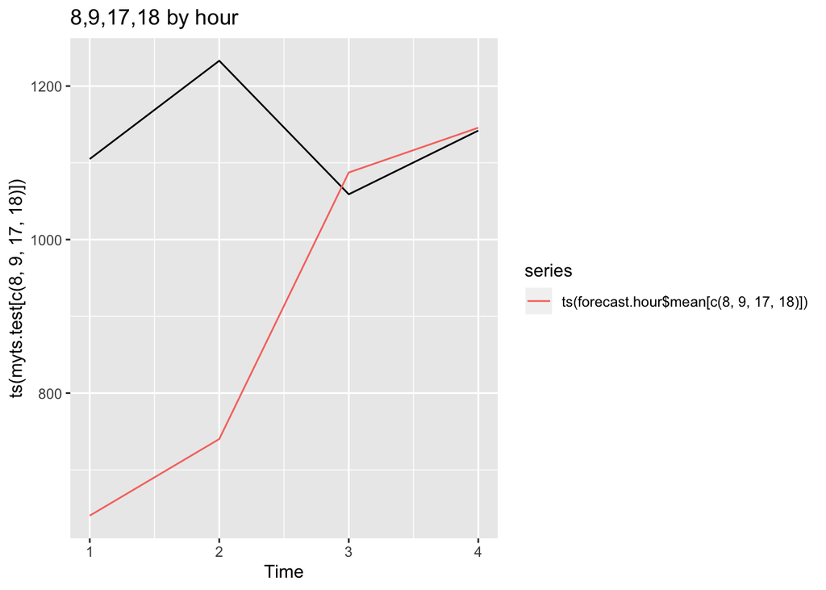

```r
autoplot(ts(myts.test[c(8,9,17,18)]))+ autolayer(ts(forecast.hour$mean[c(8,9,17,18)]))+ggtitle("8,9,17,18 by hour")
```

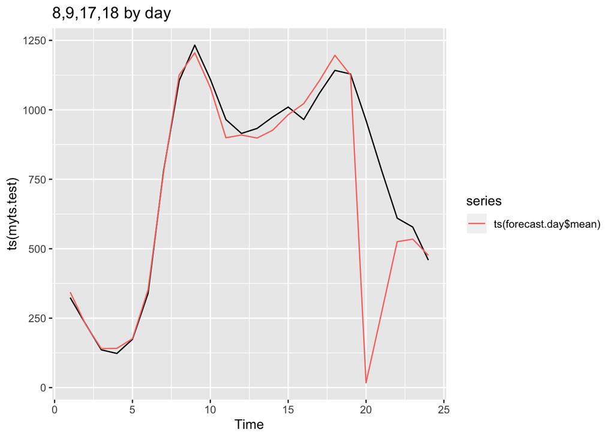

```r
autoplot(ts(myts.test))+ autolayer(ts(forecast.day$mean))+ggtitle("8,9,17,18 by day")
```

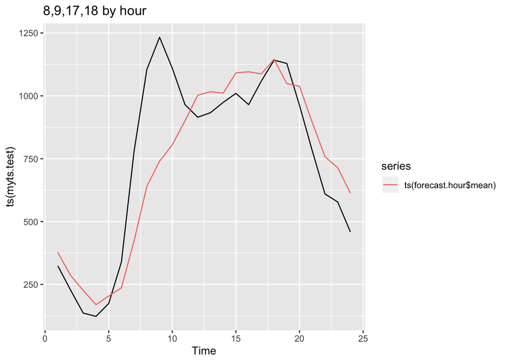

```r
autoplot(ts(myts.test))+ autolayer(ts(forecast.hour$mean))+ggtitle("8,9,17,18 by hour")
```

`day of the week seasonal Arima is better than hour of the day seasonal Arima`